# Practical Machine Learning Assignment

### Background

#### Using devices such as Jawbone Up, Nike FuelBand, and Fitbit it is now possible to collect a large amount of data about personal activity relatively inexpensively.

#### These type of devices are part of the quantified self movement - a group of enthusiasts who take measurements about themselves regularly to improve their health, to find patterns in their behavior, or because they are tech geeks.

#### One thing that people regularly do is quantify how much of a particular activity they do, but they rarely quantify how well they do it.

#### In this project, your goal will be to use data from accelerometers on the belt, forearm, arm, and dumbell of 6 participants.

#### They were asked to perform barbell lifts correctly and incorrectly in 5 different ways.

#### Data Preprocessing

##### Loading data

```r
library(caret)
```

```r
training_set <- read.csv(url("http://d396qusza40orc.cloudfront.net/predmachlearn/pml-training.csv"))
testing_set <- read.csv(url("http://d396qusza40orc.cloudfront.net/predmachlearn/pml-testing.csv"))
```

##### Partitioning the training dataset into training and testing datasets (due to small sample in testing set)

```r
training_label <- createDataPartition(training_set$classe, p=0.6, list=FALSE)
train <- training_set[training_label,]
test <- training_set[-training_label,]
```

##### Data cleaning - Preprocessing to reduce the number of variables used for analysis.

```r
#Remove variables with nearly zero variance
NZV <- nearZeroVar(train)
train <- train[,-NZV]
test <- test[,-NZV]

#Remove variables with a lot of NA terms
label <- apply(train, 2, function(x) mean(is.na(x))) > 0.90
train <- train[, -which(label, label == FALSE)]
test <- test[, -which(label, label == FALSE)]

#Remove other 5 variables used for identification
train <- train[ , -(1:5)]
test <- test[ , -(1:5)]
```

##### The number of variables have reduced from 160 to 54.

#### Exploratory Data Analysis

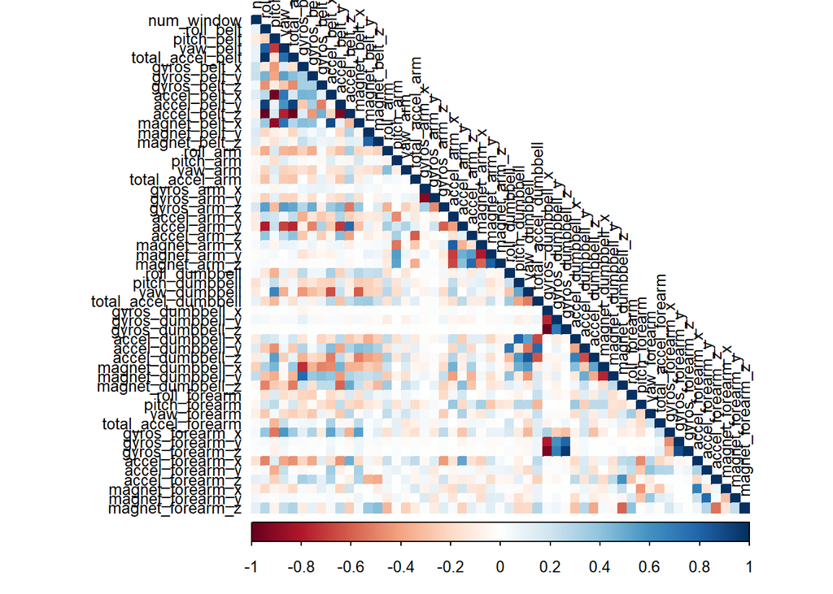

```r
#Correlation matrix between features
library(corrplot)
corrMat <- cor(train[,-54])
corrplot(corrMat, method = "color", type = "lower", tl.cex = 0.8, tl.col = rgb(0,0,0))
```

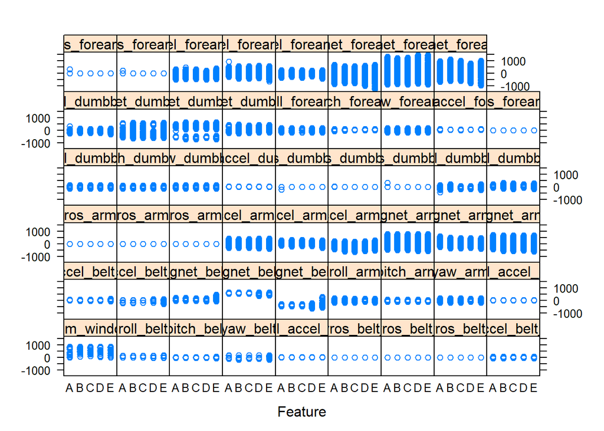

```r
# Based on the plot, the darker gradient of color corresponds to having a higher correlation.

#Correlation matrix between features and outcome
featurePlot(train[,-54], train[,54], "strip")
```

```r
# Based on the plot, each feature has relatively the same distribution among the 5 outcomes.
```

#### Prediction Model Selection - We would use 4 methods (Decision Tree, Random Forest, Generalised Boosting model and Extreme Boosting Model) on the training set and choose the model with the best accuracy to predict the outcome variable in the testing set.

#### Decision Tree

[figure not shown]

```r
library(rpart)
library(rpart.plot)
library(rattle)
set.seed(12345)
modelDT <- rpart(classe ~ ., data = train, method = "class")
fancyRpartPlot(modelDT)
```

```r
predictDT <- predict(modelDT, test, type = "class")

# Performance of the model on the test data set
confusionMatrix(predictDT, test$classe)
```

```
## Confusion Matrix and Statistics
##
##           Reference
## Prediction    A    B    C    D    E
##          A 2026  225   61   83   21
##          B   47  959   71   26   31
##          C   77  123 1064   98    5
##          D   54  140  145  984  101
##          E   28   71   27   95 1284
##
## Overall Statistics
##
##                Accuracy : 0.8051
##                  95% CI : (0.7962, 0.8138)
##     No Information Rate : 0.2845
##     P-Value [Acc > NIR] : < 2.2e-16
##
##                   Kappa : 0.753
##  Mcnemar's Test P-Value : < 2.2e-16
##
## Statistics by Class:
##
##                      Class: A Class: B Class: C Class: D Class: E
## Sensitivity            0.9077   0.6318   0.7778   0.7652   0.8904
## Specificity            0.9305   0.9723   0.9532   0.9329   0.9655
## Pos Pred Value         0.8386   0.8457   0.7783   0.6910   0.8532
## Neg Pred Value         0.9621   0.9167   0.9531   0.9530   0.9751
## Prevalence             0.2845   0.1935   0.1744   0.1639   0.1838
## Detection Rate         0.2582   0.1222   0.1356   0.1254   0.1637
## Detection Prevalence   0.3079   0.1445   0.1742   0.1815   0.1918
## Balanced Accuracy      0.9191   0.8020   0.8655   0.8490   0.9280
```

#### Random Forest

```r
library(randomForest)
modelRF <- randomForest(classe ~ ., data = train, importance = TRUE)
modelRF
```

```
##
## Call:
##  randomForest(formula = classe ~ ., data = train, importance = TRUE)
##                Type of random forest: classification
##                      Number of trees: 500
## No. of variables tried at each split: 7
##
##         OOB estimate of  error rate: 0.33%
## Confusion matrix:
##      A    B    C    D    E  class.error
## A 3347    0    0    0    1 0.0002986858
## B    8 2268    3    0    0 0.0048266784
## C    0    8 2046    0    0 0.0038948393
## D    0    0   17 1913    0 0.0088082902
## E    0    0    0    2 2163 0.0009237875
```

```r
predictRF <- predict(modelRF, test, type = "class")

# Performance of the model on the test data set
confusionMatrix(predictRF, test$classe)
```

```
## Confusion Matrix and Statistics
##
##           Reference
## Prediction    A    B    C    D    E
##          A 2230    6    0    0    0
##          B    2 1510    4    0    0
##          C    0    2 1364   11    0
##          D    0    0    0 1269    8
##          E    0    0    0    6 1434
##
## Overall Statistics
##
##                Accuracy : 0.995
##                  95% CI : (0.9932, 0.9965)
##     No Information Rate : 0.2845
##     P-Value [Acc > NIR] : < 2.2e-16
##
##                   Kappa : 0.9937
##  Mcnemar's Test P-Value : NA
##
## Statistics by Class:
##
##                      Class: A Class: B Class: C Class: D Class: E
## Sensitivity            0.9991   0.9947   0.9971   0.9868   0.9945
## Specificity            0.9989   0.9991   0.9980   0.9988   0.9991
## Pos Pred Value         0.9973   0.9960   0.9906   0.9937   0.9958
## Neg Pred Value         0.9996   0.9987   0.9994   0.9974   0.9988
## Prevalence             0.2845   0.1935   0.1744   0.1639   0.1838
## Detection Rate         0.2842   0.1925   0.1738   0.1617   0.1828
## Detection Prevalence   0.2850   0.1932   0.1755   0.1628   0.1835
## Balanced Accuracy      0.9990   0.9969   0.9975   0.9928   0.9968
```

#### Generalised Boosting Model

```r
library(caret)
set.seed(12345)
controlGBM <- trainControl(method = "repeatedcv", number = 5, repeats = 1, verboseIter = FALSE)
modelGBM <- train(classe ~ ., data = train, trControl = controlGBM, method = "gbm", verbose = FALSE)
modelGBM$finalModel
```

```
## A gradient boosted model with multinomial loss function.
## 150 iterations were performed.
## There were 53 predictors of which 43 had non-zero influence.
```

```r
predictGBM <- predict(modelGBM, test)
confusionMatrix(predictGBM, test$classe)
```

```
## Confusion Matrix and Statistics
##
##           Reference
## Prediction    A    B    C    D    E
##          A 2222   19    0    2    0
##          B   10 1480    7   10    6
##          C    0   17 1357   20    4
##          D    0    2    4 1253   14
##          E    0    0    0    1 1418
##
## Overall Statistics
##
##                Accuracy : 0.9852
##                  95% CI : (0.9823, 0.9878)
##     No Information Rate : 0.2845
##     P-Value [Acc > NIR] : < 2.2e-16
##
##                   Kappa : 0.9813
##  Mcnemar's Test P-Value : NA
##
## Statistics by Class:
##
##                      Class: A Class: B Class: C Class: D Class: E
## Sensitivity            0.9955   0.9750   0.9920   0.9743   0.9834
## Specificity            0.9963   0.9948   0.9937   0.9970   0.9998
## Pos Pred Value         0.9906   0.9782   0.9707   0.9843   0.9993
## Neg Pred Value         0.9982   0.9940   0.9983   0.9950   0.9963
## Prevalence             0.2845   0.1935   0.1744   0.1639   0.1838
## Detection Rate         0.2832   0.1886   0.1730   0.1597   0.1807
## Detection Prevalence   0.2859   0.1928   0.1782   0.1622   0.1809
## Balanced Accuracy      0.9959   0.9849   0.9928   0.9856   0.9916
```

#### Extreme Gradient Boosting - We have chosen this additional model due to its good accuracy and having a good reputation as a leading model in Kaggle competitions.

```r
library(xgboost)
set.seed(12345)
controlXGB <- trainControl(method = "cv", number = 5, allowParallel = TRUE)
modelXGB <- train(classe ~ ., data = train, method = "xgbTree", trControl = controlXGB)
modelXGB
```

```
## eXtreme Gradient Boosting
##
## 11776 samples
##    53 predictor
##     5 classes: 'A', 'B', 'C', 'D', 'E'
##
## No pre-processing
## Resampling: Cross-Validated (5 fold)
## Summary of sample sizes: 9421, 9421, 9422, 9420, 9420
## Resampling results across tuning parameters:
##
##   eta  max_depth  colsample_bytree  subsample  nrounds  Accuracy
##   0.3  1          0.6               0.50        50      0.8134342
##   0.3  1          0.6               0.50       100      0.8818775
##   0.3  1          0.6               0.50       150      0.9139768
##   0.3  1          0.6               0.75        50      0.8068953
##   0.3  1          0.6               0.75       100      0.8812829
##   0.3  1          0.6               0.75       150      0.9137222
##   0.3  1          0.6               1.00        50      0.8116498
##   0.3  1          0.6               1.00       100      0.8824716
##   0.3  1          0.6               1.00       150      0.9141466
##   0.3  1          0.8               0.50        50      0.8135187
##   0.3  1          0.8               0.50       100      0.8859541
##   0.3  1          0.8               0.50       150      0.9178829
##   0.3  1          0.8               0.75        50      0.8136878
##   0.3  1          0.8               0.75       100      0.8841700
##   0.3  1          0.8               0.75       150      0.9158449
##   0.3  1          0.8               1.00        50      0.8123291
##   0.3  1          0.8               1.00       100      0.8834060
##   0.3  1          0.8               1.00       150      0.9141464
##   0.3  2          0.6               0.50        50      0.9487086
##   0.3  2          0.6               0.50       100      0.9847993
##   0.3  2          0.6               0.50       150      0.9942250
##   0.3  2          0.6               0.75        50      0.9515954
##   0.3  2          0.6               0.75       100      0.9861577
##   0.3  2          0.6               0.75       150      0.9943100
##   0.3  2          0.6               1.00        50      0.9543126
##   0.3  2          0.6               1.00       100      0.9883653
##   0.3  2          0.6               1.00       150      0.9960935
##   0.3  2          0.8               0.50        50      0.9537185
```

[output cut: 182 more lines]

```
##   0.9987110
##   0.9930183
##   0.9980666
##   0.9989260
##   0.9949513
##   0.9990333
##   0.9991407
##
## Tuning parameter 'gamma' was held constant at a value of 0
##
## Tuning parameter 'min_child_weight' was held constant at a value of 1
## Accuracy was used to select the optimal model using the largest value.
## The final values used for the model were nrounds = 150, max_depth = 3,
##  eta = 0.4, gamma = 0, colsample_bytree = 0.6, min_child_weight = 1
##  and subsample = 0.75.
```

```r
predictXGB <- predict(modelXGB, test)

# Performance of the model on the test data set
confusionMatrix(predictXGB, test$classe)
```

```
## Confusion Matrix and Statistics
##
##           Reference
## Prediction    A    B    C    D    E
##          A 2232    3    0    0    0
##          B    0 1515    3    0    0
##          C    0    0 1363    0    0
##          D    0    0    2 1286    5
##          E    0    0    0    0 1437
##
## Overall Statistics
##
##                Accuracy : 0.9983
##                  95% CI : (0.9972, 0.9991)
##     No Information Rate : 0.2845
##     P-Value [Acc > NIR] : < 2.2e-16
##
##                   Kappa : 0.9979
##  Mcnemar's Test P-Value : NA
##
## Statistics by Class:
##
##                      Class: A Class: B Class: C Class: D Class: E
## Sensitivity            1.0000   0.9980   0.9963   1.0000   0.9965
## Specificity            0.9995   0.9995   1.0000   0.9989   1.0000
## Pos Pred Value         0.9987   0.9980   1.0000   0.9946   1.0000
## Neg Pred Value         1.0000   0.9995   0.9992   1.0000   0.9992
## Prevalence             0.2845   0.1935   0.1744   0.1639   0.1838
## Detection Rate         0.2845   0.1931   0.1737   0.1639   0.1832
## Detection Prevalence   0.2849   0.1935   0.1737   0.1648   0.1832
## Balanced Accuracy      0.9997   0.9988   0.9982   0.9995   0.9983
```

#### Predicting test data output

```r
predictXGB_testingset <- predict(modelXGB, testing_set)
predictXGB_testingset
```

```
##  [1] B A B A A E D B A A B C B A E E A B B B
## Levels: A B C D E
```